# Desert Bird Habitat Use

## Checking Factors and Models

### Correlation, colinearity, and multicolinearity

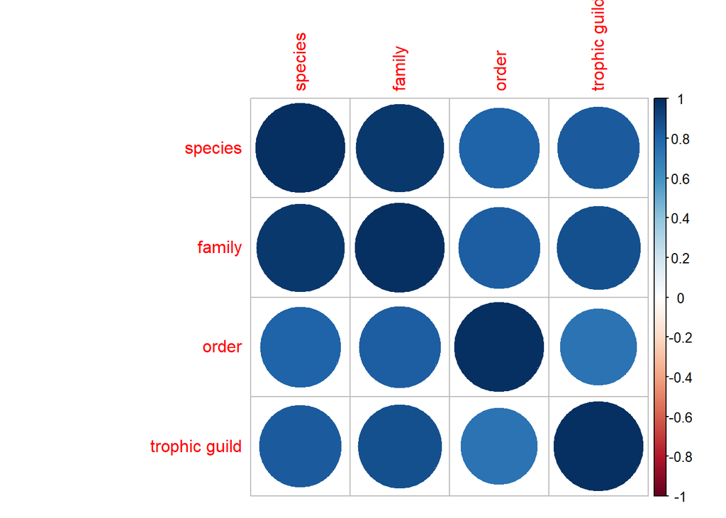

## Diversity

### Species and three mesohabitat levels

```r
#pca1 <- rda(ssp.3.wide)

#step1 <- step(lm(mpg~wt+drat+disp+qsec,data=mtcars),direction="both")
```

### Chi-squared Tests

We’ve agreed these are wrong. But for now, let’s keep them accessible.

```r
ssp.abundance <- data.frame(table(site$season, site$species))
species.wide <- spread(ssp.abundance, Var2, Freq)
rownames(species.wide) <- species.wide$Var1
species.wide$Var1 <- NULL
chisq.test(species.wide)
```

```
##
##  Pearson's Chi-squared test
##
## data:  species.wide
## X-squared = 284.16, df = 42, p-value < 2.2e-16
```

```r
fam.abundance<-data.frame(table(site$season, site$family))
fam.wide <- spread(fam.abundance, Var2, Freq)
rownames(fam.wide) <- fam.wide$Var1
fam.wide$Var1 <- NULL
chisq.test(fam.wide)
```

```
##
##  Pearson's Chi-squared test
##
## data:  fam.wide
## X-squared = 199.85, df = 20, p-value < 2.2e-16
```

```r
order.abundance <- data.frame(table(site$season, site$order))
order.wide <- spread(order.abundance, Var2, Freq)
rownames(order.wide) <- order.wide$Var1
order.wide$Var1 <- NULL
chisq.test(order.wide)
```

```
##
##  Pearson's Chi-squared test
##
## data:  order.wide
## X-squared = 71.651, df = 6, p-value = 1.874e-13
```

The test is significant for all taxanomic levels of actual abundance, but may not be the correct statistical test? All it tells us is there is a difference between migration and breeding seasons in regards to abundance (we know migration has higher abundance, but how so?). This is not super helpful. I wanted to do a redunancy analysis, but considering the independant factor isn’t numeric, I’m not sure how to go about further. Perhaps, we should do just a t-test of Shannon-Weaver Indices? This way, we are also involving diversity, not just abundance.

Additionally, I am concerned because this chi-squared test doesn’t incorporate the different levels of replication.